# E[TBC] — Expected Time Before Contact with QB

A geometric player-grading metric for pass blockers and rushers

# What is E[TBC]?

> **E[TBC] is the expected number of seconds until a specific pass rusher physically reaches the QB**, given the rusher’s current position, speed, and direction.

It answers the only question coaches actually ask in real time: *“how much time does my QB have?”*

## The math

For every rusher on every frame, using only that frame’s snapshot:

$$E[TBC] = \frac{\text{distance from rusher to QB}}{\text{closing speed along rusher} \rightarrow \text{QB direction}}$$

- If the rusher is not moving toward the QB → E[TBC] = ∞
- If the rusher is already within 1 yard of the QB → E[TBC] = 0 (contact made)
- Otherwise: distance ÷ closing speed, in seconds

## Relationship to PRSS

|  | **PRSS** | **E[TBC]** |
| --- | --- | --- |
| Unit | sq yards / frame | seconds |
| Measures | how fast space is disappearing | when contact will happen |
| Looks | backward | forward |
| Grades | offensive line as a unit | individual rushers and blockers |
| Rolling window? | yes (k = 5 frames) | no — per-frame |

**PRSS tells you the pocket is shrinking. E[TBC] tells you who’s about to break it, and when.**

# Rusher Rankings

A rusher’s E[TBC] grade = the **median E[TBC] they generate** across all their pass-rush frames. **Lower = better rusher** (they reach the QB faster).

## Top 20 pass rushers (DL + LB, ≥ 50 plays)

| Rank | Player | Position | Plays | Median E[TBC] (s) | Mean E[TBC] (s) | % under 2s | % under 1s |
| --- | --- | --- | --- | --- | --- | --- | --- |
| 1 | Leonard Floyd | OLB | 200 | 3.17 | 4.39 | 28.9% | 7.0% |
| 2 | Justin Houston | OLB | 138 | 3.30 | 4.58 | 25.0% | 6.2% |
| 3 | Kyler Fackrell | OLB | 78 | 3.33 | 4.58 | 23.0% | 4.2% |
| 4 | Josh Allen | OLB | 166 | 3.37 | 4.49 | 24.0% | 7.1% |
| 5 | Yannick Ngakoue | DE | 198 | 3.44 | 4.53 | 22.1% | 6.1% |
| 6 | Justin Hollins | OLB | 69 | 3.50 | 4.76 | 23.6% | 3.3% |
| 7 | Alex Highsmith | OLB | 136 | 3.50 | 4.67 | 20.4% | 5.4% |
| 8 | Joey Bosa | OLB | 179 | 3.52 | 4.77 | 23.5% | 6.0% |
| 9 | Rashan Gary | OLB | 196 | 3.54 | 4.68 | 25.3% | 7.0% |
| 10 | Preston Smith | OLB | 136 | 3.56 | 4.75 | 20.6% | 4.2% |
| 11 | K’Lavon Chaisson | OLB | 62 | 3.57 | 4.79 | 21.3% | 7.9% |
| 12 | Myles Garrett | DE | 207 | 3.61 | 4.67 | 25.7% | 9.1% |
| 13 | Olasunkanmi Adeniyi | OLB | 86 | 3.62 | 4.69 | 20.4% | 7.0% |
| 14 | Josh Uche | OLB | 104 | 3.63 | 4.82 | 17.9% | 3.8% |
| 15 | T.J. Watt | OLB | 154 | 3.66 | 4.83 | 24.1% | 6.8% |
| 16 | Tyus Bowser | OLB | 108 | 3.67 | 4.92 | 23.2% | 5.9% |
| 17 | Khalil Mack | OLB | 142 | 3.69 | 4.86 | 24.9% | 7.1% |
| 18 | Bryce Huff | DE | 133 | 3.70 | 4.82 | 19.3% | 5.1% |
| 19 | Takkarist McKinley | DE | 120 | 3.71 | 4.65 | 24.4% | 7.3% |
| 20 | Von Miller | OLB | 159 | 3.73 | 4.89 | 24.6% | 7.5% |

# Offensive Line Rankings

A blocker’s E[TBC] grade = the **median E[TBC] of the rusher they were assigned to block** (per PFF’s `pff_nflIdBlockedPlayer`). **Higher = better blocker** (their assigned rusher stayed further from the QB).

## Top 15 Centers

| Rank | Player | Plays | Median E[TBC] (s) | PFF pressure-allowed rate |
| --- | --- | --- | --- | --- |
| 1 | Rodney Hudson | 138 | 9.73 | 0.0% |
| 2 | Creed Humphrey | 301 | 8.89 | 2.7% |
| 3 | Mitch Morse | 236 | 7.59 | 4.2% |
| 4 | Erik McCoy | 74 | 7.55 | 1.4% |
| 5 | Max Garcia | 107 | 7.36 | 1.9% |
| 6 | Frank Ragnow | 119 | 7.27 | 3.4% |
| 7 | Ryan Jensen | 291 | 7.19 | 4.5% |
| 8 | Evan Brown | 181 | 7.13 | 2.8% |
| 9 | J.C. Tretter | 221 | 7.00 | 2.7% |
| 10 | Greg Mancz | 110 | 6.90 | 2.7% |
| 11 | Brian Allen | 228 | 6.71 | 5.3% |
| 12 | Corey Linsley | 253 | 6.66 | 1.6% |
| 13 | Kendrick Green | 218 | 6.60 | 3.7% |
| 14 | Michael Deiter | 112 | 6.58 | 4.5% |
| 15 | Josh Myers | 103 | 6.52 | 4.9% |

## Top 15 Guards

| Rank | Player | Plays | Median E[TBC] (s) | PFF pressure-allowed rate |
| --- | --- | --- | --- | --- |
| 1 | Ike Boettger | 55 | 8.23 | 5.5% |
| 2 | Cody Ford | 117 | 7.68 | 15.4% |
| 3 | Trey Smith | 319 | 7.67 | 6.9% |
| 4 | Lucas Patrick | 126 | 7.39 | 4.8% |
| 5 | Joe Thuney | 314 | 7.31 | 3.2% |
| 6 | Justin Pugh | 212 | 7.26 | 6.1% |
| 7 | Jon Runyan | 186 | 7.20 | 6.5% |
| 8 | Cesar Ruiz | 189 | 7.07 | 5.8% |
| 9 | Jon Feliciano | 214 | 7.03 | 7.0% |
| 10 | Joel Bitonio | 230 | 7.01 | 3.0% |
| 11 | Oday Aboushi | 162 | 6.89 | 3.1% |
| 12 | Wyatt Teller | 230 | 6.83 | 6.5% |
| 13 | Jonah Jackson | 308 | 6.81 | 8.4% |
| 14 | Josh Jones | 220 | 6.74 | 8.6% |
| 15 | Michael Schofield | 106 | 6.74 | 3.8% |

## Top 15 Tackles

| Rank | Player | Plays | Median E[TBC] (s) | PFF pressure-allowed rate |
| --- | --- | --- | --- | --- |
| 1 | James Hudson | 53 | 6.72 | 11.3% |
| 2 | Spencer Brown | 93 | 6.59 | 8.6% |
| 3 | Royce Newman | 216 | 6.44 | 5.1% |
| 4 | Jamarco Jones | 62 | 6.12 | 9.7% |
| 5 | Olisaemeka Udoh | 244 | 6.06 | 8.2% |
| 6 | La’el Collins | 53 | 5.95 | 7.5% |
| 7 | James Hurst | 114 | 5.84 | 4.4% |
| 8 | Jedrick Wills | 139 | 5.79 | 12.9% |
| 9 | Calvin Throckmorton | 145 | 5.75 | 7.6% |
| 10 | Tytus Howard | 232 | 5.71 | 7.8% |
| 11 | Storm Norton | 240 | 5.65 | 12.9% |
| 12 | Daryl Williams | 242 | 5.65 | 7.4% |
| 13 | Jack Conklin | 144 | 5.61 | 5.6% |
| 14 | George Fant | 221 | 5.33 | 4.5% |
| 15 | Ben Bartch | 121 | 5.29 | 6.6% |

## Bottom 15 OL across all positions

| Rank | Player | Position | Plays | Median E[TBC] (s) | PFF pressure-allowed rate |
| --- | --- | --- | --- | --- | --- |
| 1 | Dan Moore | T | 227 | 3.21 | 10.6% |
| 2 | Joe Haeg | T | 72 | 3.33 | 1.4% |
| 3 | Jason Peters | T | 214 | 3.56 | 6.5% |
| 4 | Elijah Wilkinson | T | 58 | 3.56 | 10.3% |
| 5 | Garett Bolles | T | 271 | 3.57 | 6.3% |
| 6 | Jonah Williams | T | 247 | 3.59 | 6.5% |
| 7 | Taylor Lewan | T | 174 | 3.65 | 6.3% |
| 8 | Laremy Tunsil | T | 119 | 3.66 | 5.9% |
| 9 | Andre Dillard | T | 157 | 3.71 | 9.6% |
| 10 | Jawaan Taylor | T | 252 | 3.75 | 6.7% |
| 11 | Penei Sewell | T | 316 | 3.92 | 8.5% |
| 12 | Germain Ifedi | T | 125 | 3.95 | 4.0% |
| 13 | Eric Fisher | T | 206 | 3.98 | 10.7% |
| 14 | Julien Davenport | T | 114 | 4.01 | 14.9% |
| 15 | Tristan Wirfs | T | 294 | 4.01 | 2.7% |

# Head-to-head: E[TBC] vs. PFF Pressure-Allowed Rate

If E[TBC] and PFF measured the same thing, we’d see a **strong negative correlation** (higher E[TBC] should mean lower pressure rate).

| Position | n OL | Spearman r | Pearson r |
| --- | --- | --- | --- |
| C | 48 | -0.570 | -0.558 |
| G | 88 | -0.193 | -0.297 |
| T | 110 | 0.038 | 0.064 |

**Key finding:** Centers show strong agreement (r ≈ -0.57). Tackles show essentially **no relationship** (r ≈ 0.04). PFF’s grades for the most-paid position group on the OL may not be measuring what people think they measure.

## Scatter plot

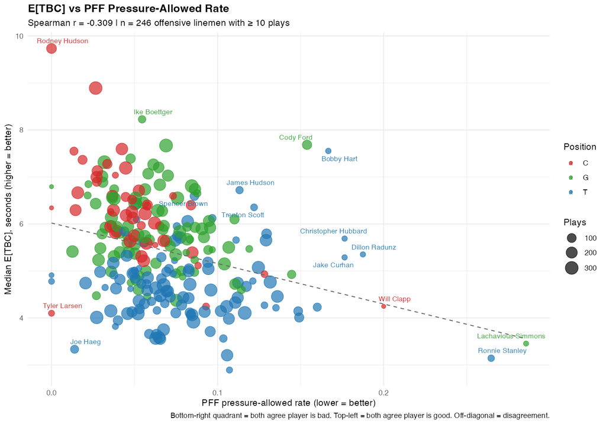

Lower-right quadrant = both metrics say the player is bad. Upper-left = both say good. Off-diagonal = disagreement between metrics.

## Notable disagreements (potential talking points)

| Player | Position | Plays | Median E[TBC] (s) | PFF pressure rate | E[TBC] z-score | PFF z-score | Disagreement |
| --- | --- | --- | --- | --- | --- | --- | --- |
| Cody Ford | G | 117 | 7.68 | 15.4% | 2.08 | -2.39 | 4.46 |
| Joe Haeg | T | 72 | 3.33 | 1.4% | -1.69 | 1.63 | 3.31 |
| James Hudson | T | 53 | 6.72 | 11.3% | 2.51 | -0.79 | 3.30 |
| Trenton Scott | T | 41 | 6.35 | 12.2% | 2.05 | -1.00 | 3.05 |
| Isaac Seumalo | G | 74 | 4.47 | 2.7% | -1.60 | 1.06 | 2.66 |
| Ronnie Stanley | T | 34 | 3.14 | 26.5% | -1.92 | -4.47 | 2.55 |
| Jedrick Wills | T | 139 | 5.79 | 12.9% | 1.36 | -1.18 | 2.54 |
| Spencer Brown | T | 93 | 6.59 | 8.6% | 2.35 | -0.13 | 2.48 |
| Ike Boettger | G | 55 | 8.23 | 5.5% | 2.70 | 0.31 | 2.39 |
| Storm Norton | T | 240 | 5.65 | 12.9% | 1.19 | -1.18 | 2.36 |

# Method notes

- **Tracking data**: NFL Big Data Bowl 2022 (2021 season, weeks 1–8)
- **Pass rusher / blocker identification**: PFF scouting data (`pff_role`)
- **Blocker-rusher assignment**: PFF’s `pff_nflIdBlockedPlayer`
- **Pass plays**: only frames between snap and ball release / sack / spike
- **Sample size threshold**: ≥ 50 plays for headline rankings; ≥ 10 for the comparison
- **Position adjustment**: PFF correlation analysis is computed within position to control for the structural difference between tackle and interior matchups

## Parameters

| Parameter | Value | Purpose |
| --- | --- | --- |
| `CONTACT_RADIUS` | 1.0 yd | Distance at which “contact” is declared |
| `MAX_ETBC` | 10.0 s | Cap for aggregation sanity |
| `FPS` | 10 | Tracking data frame rate |

## Limitations

1. **Position bias**: tackles face edge rushers (longer arc) → lower natural E[TBC] than interior. Comparisons should be within position.
2. **Twists / stunts**: PFF’s blocker-rusher assignment is imperfect when defenders cross. About 5–10% of reps are ambiguous.
3. **Blocker obstacle effect**: current model is pure kinematics — doesn’t model the blocker as an obstacle. A rusher engaged with a blocker still gets credit for closing speed.
4. **8-week sample**: production rankings would benefit from a full season.